# Exploratory Data Analysis on Loan Data from Prosper by Minu Aravind

## 1.INTRODUCTION:

Prosper Marketplace is a peer-to-peer lending industry,where individuals can either invest in personal loans or request to borrow money.Here we use the ‘Prosper Loan Data’ data available to the public(last updated on March 11th, 2014) to do some data analysis.The dataset contains 113,937 loans with 81 variables on each loan.

## 2.Exploratory Data Analysis:

The process will be done in following 4 steps. 1.Preparing data 2.Analysis: 2.1.Univariate analysis and plots 2.2.2Bivariate analysis and plots 2.3Multivariate analysis and plots 3.Final plots and summary 4.Reflection

# 1.Preparing Data

```
## [1] 113937     81
```

```
## 'data.frame':    113937 obs. of  81 variables:
##  $ ListingKey                         : Factor w/ 113066 levels "00003546482094282EF90E5",..: 7180 7193 6647 6669 6686 6689 6699 6706 6687 6687 ...
##  $ ListingNumber                      : int  193129 1209647 81716 658116 909464 1074836 750899 768193 1023355 1023355 ...
##  $ ListingCreationDate                : Factor w/ 113064 levels "2005-11-09 20:44:28.847000000",..: 14184 111894 6429 64760 85967 100310 72556 74019 97834 97834 ...
##  $ CreditGrade                        : Factor w/ 9 levels "","A","AA","B",..: 5 1 8 1 1 1 1 1 1 1 ...
##  $ Term                               : int  36 36 36 36 36 60 36 36 36 36 ...
##  $ LoanStatus                         : Factor w/ 12 levels "Cancelled","Chargedoff",..: 3 4 3 4 4 4 4 4 4 4 ...
##  $ ClosedDate                         : Factor w/ 2803 levels "","2005-11-25 00:00:00",..: 1138 1 1263 1 1 1 1 1 1 1 ...
##  $ BorrowerAPR                        : num  0.165 0.12 0.283 0.125 0.246 ...
##  $ BorrowerRate                       : num  0.158 0.092 0.275 0.0974 0.2085 ...
##  $ LenderYield                        : num  0.138 0.082 0.24 0.0874 0.1985 ...
##  $ EstimatedEffectiveYield            : num  NA 0.0796 NA 0.0849 0.1832 ...
##  $ EstimatedLoss                      : num  NA 0.0249 NA 0.0249 0.0925 ...
##  $ EstimatedReturn                    : num  NA 0.0547 NA 0.06 0.0907 ...
##  $ ProsperRating..numeric.            : int  NA 6 NA 6 3 5 2 4 7 7 ...
```

[output cut: 67 more lines]

```
##  [1] "ListingKey"
##  [2] "ListingNumber"
##  [3] "ListingCreationDate"
##  [4] "CreditGrade"
##  [5] "Term"
##  [6] "LoanStatus"
##  [7] "ClosedDate"
##  [8] "BorrowerAPR"
##  [9] "BorrowerRate"
## [10] "LenderYield"
## [11] "EstimatedEffectiveYield"
## [12] "EstimatedLoss"
## [13] "EstimatedReturn"
## [14] "ProsperRating..numeric."
## [15] "ProsperRating..Alpha."
```

[output cut: 66 more lines]

Creating new variables to meet the future requirements:

1.Create Listing Category :

2. Create LoanOriginationQuarter_factor:

While creating plots inorder to display LoanOriginationQuarter in chronological order along the x-axis we need to convert it to a date series order.

3.create LoanStatusRecoded:

While creating plots inorder to use the category of Defaulted Loans, we are recoding the Loanstatus variable.Summary of LoanStatusRecoded will clearly show the newly created 4 categories of LoanStatus.

```
## Defaulted  Past Due   Current Completed
##     17015      2067     56781     38074
```

4.Create CreditScore;

To create a new variable CreditScore by finding the average of CreditScoreRangeLower and CreditScoreRangeUpper.

[output not shown]

5.Create CreditRating :

CreditGrade is the Credit rating that was assigned at the time the listing went live. Applicable for listings pre-2009 period and will only be populated for those listings. ProsperRating (Alpha) is the Prosper Rating assigned at the time the listing was created between AA - HR. Applicable for loans originated after July 2009.Here we Join the CreditGrade and ProsperRating..Alpha.

6.Create LoanPaymentPercentage:

I created the new variable LoanPaymentPercentage as the ratio of LoanOriginalAmount and MonthlyLoanPayment.

```
##  LoanPaymentPercentage
##  Min.   :   10.43
##  1st Qu.:   25.51
##  Median :   28.85
##  Mean   :   30.89
##  3rd Qu.:   31.91
##  Max.   :20000.00
```

7.Create CurrentDelinquencies_factored :

# Analysis:

# 1. Univariate Plots Section:

Plot of Loan Original Amount:

Since I’m dealing with loan data, the first thing I want to check is the loan amounts being requested. Let’s make a simple histogram showing just that:

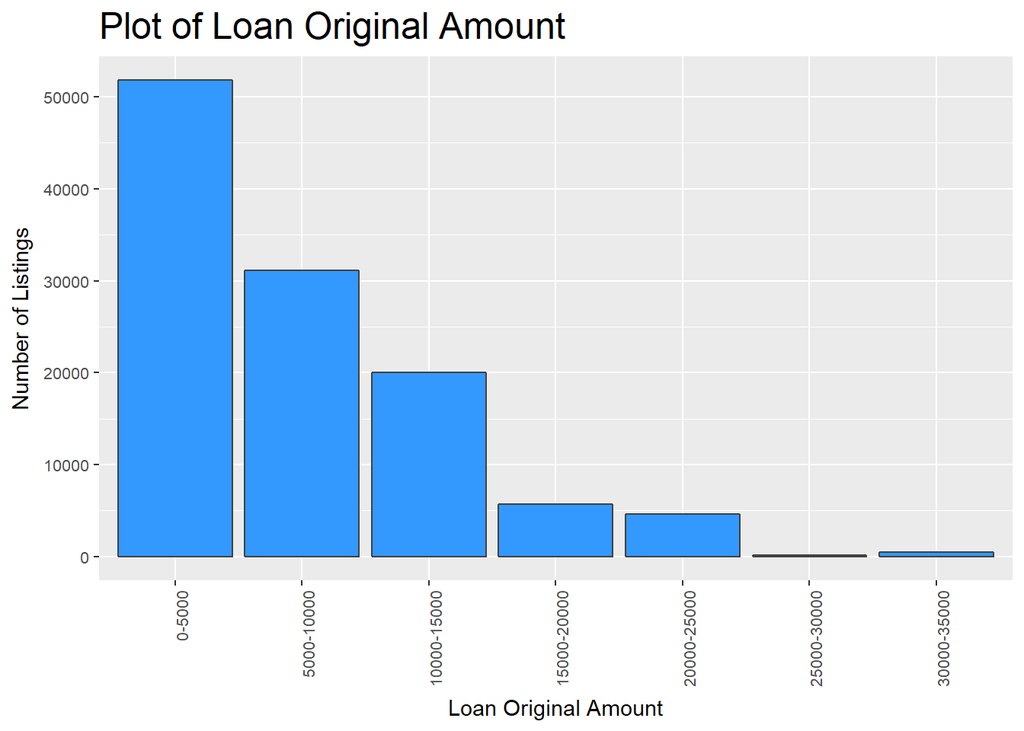

Plot of Loan Origination in Years:

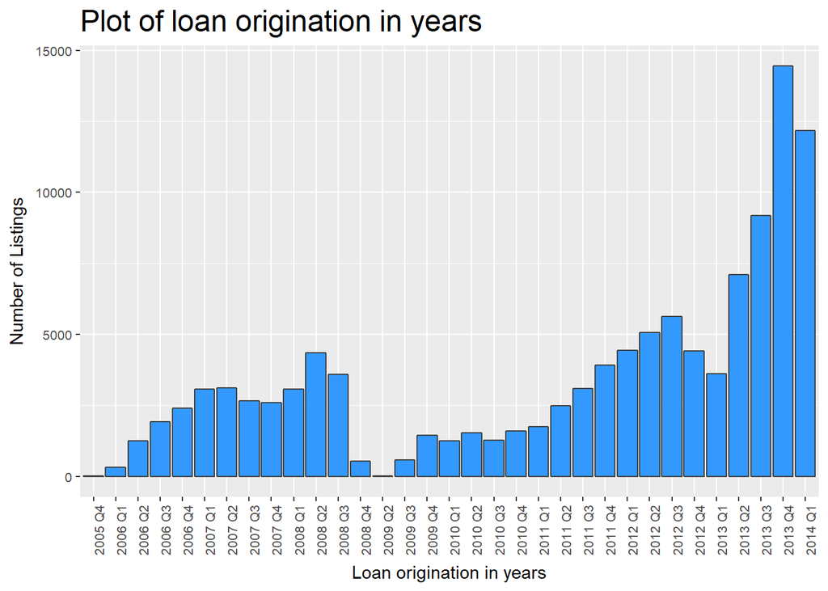

Looking at the plot we can see that 30% of all loans were originated in 2013 followed by 17% in 2012. Only about 1.8% originated in 2009.

Plot of LoanStatus :

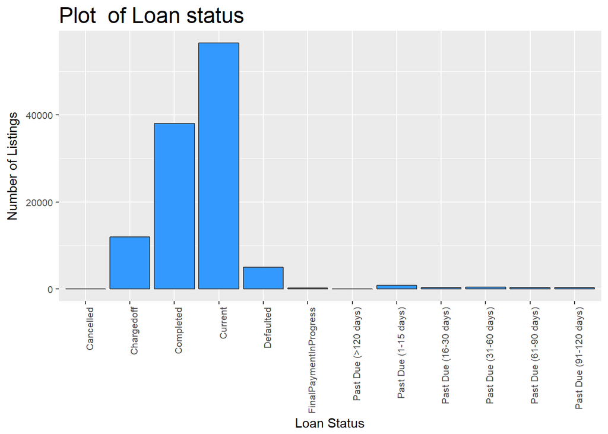

Most of the LoanStatus belong to the caregory of ‘current’,This is an indication on the progress the Prosper Marketplace is making.

Plot of Listing Category:

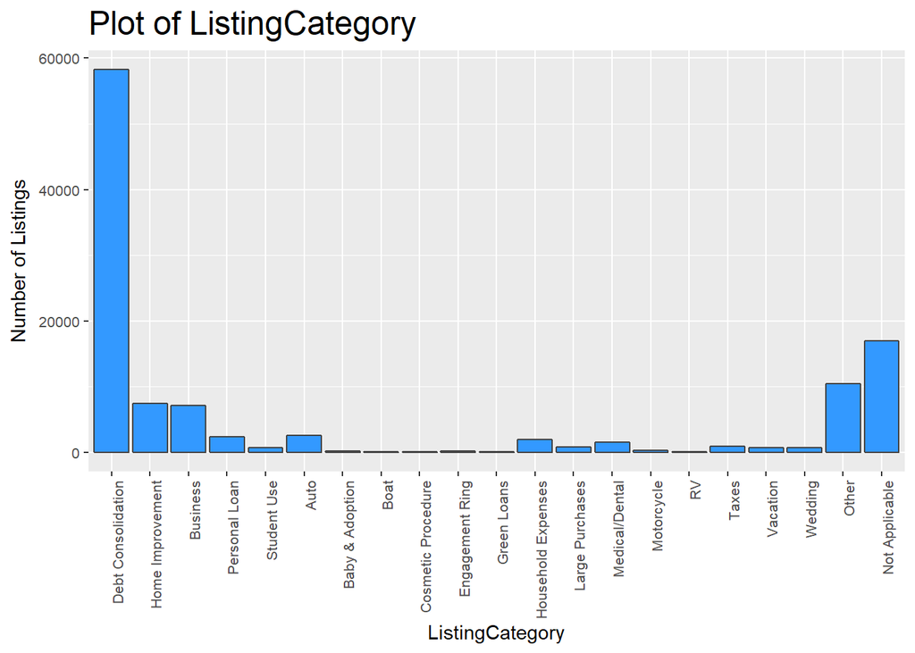

We can see that one of the most popular purposes for Prosper personal loans is debt consolidation,may be to pay off credit card debts etc.Prosper personal loans being installment debts may be one of the reason for this huge spike in the category of debt consolidation.

Plot of Loan Monthly payment :

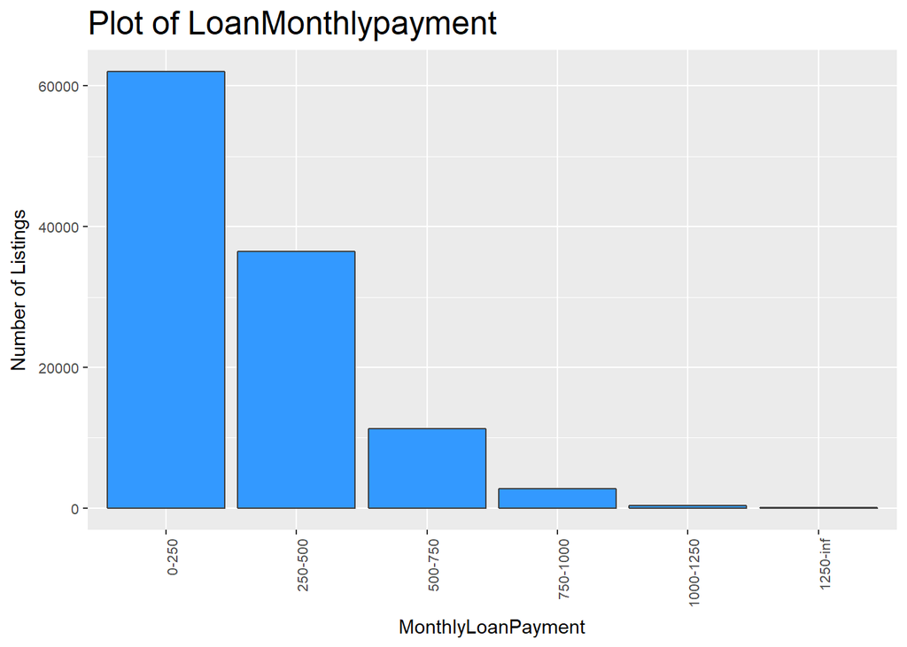

We can observe that the loan monthly payment peaks between the values of 0 and 250.

Plot of LoanPaymentPercentage :

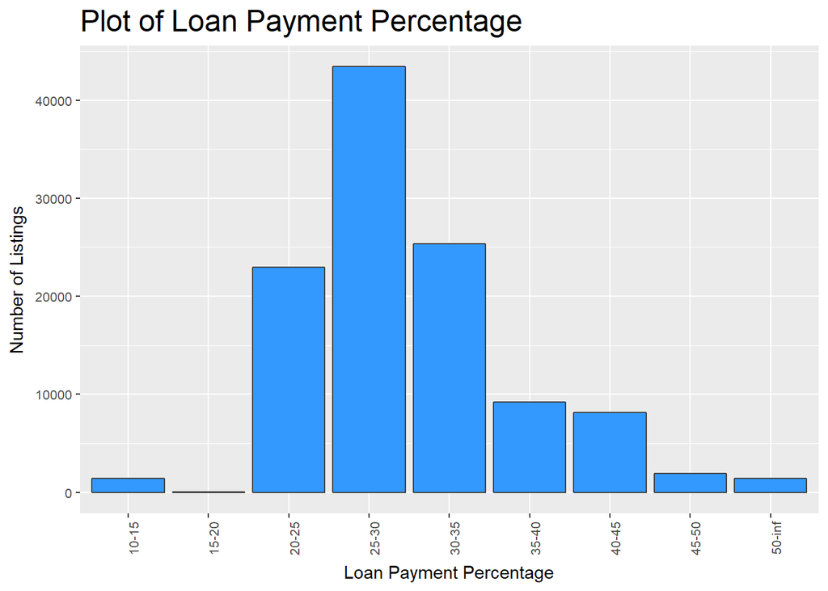

Plot of StatedMonthlyIncome :

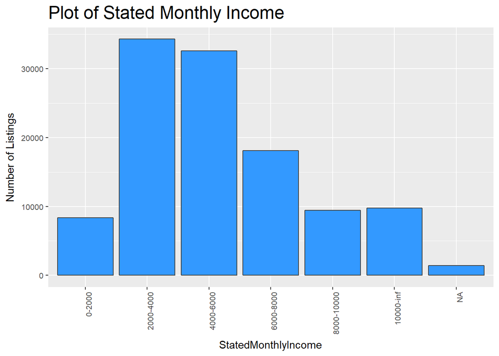

Looking at the plot a majority of borrowers actually indicates a monthly income below 6,000 USD. It is important to note that I have also limited the x-Axis since some borrowers indicated a monthly income of more than 25.000 USD. Those are likely to be outliers.

Plot of Credit Grade and Prosper Rating(Alpha):

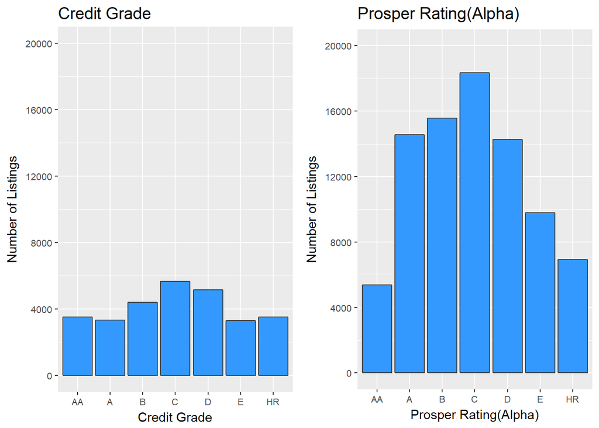

This is a grid of CreditGrade and ProsperRating side by side. In both plots there are less borrowers in the both ends of the credit rating. This may be because most people with good credit usually don’t take loans or they might not be taking these kind of loans with a smaller principle amount,as they might have bigger needs or as they are financially stable.While people at the tail-end of the credit rating don’t always get approved for credits.

Plot of ProsperSCore :

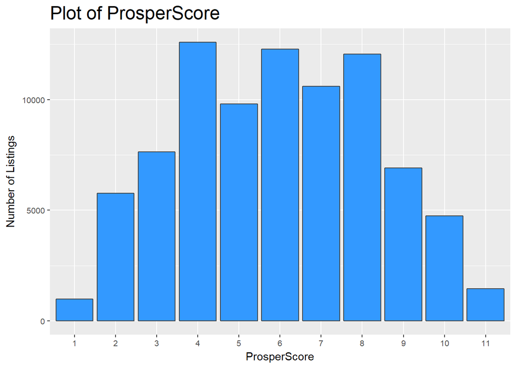

Plot of Credit Score :

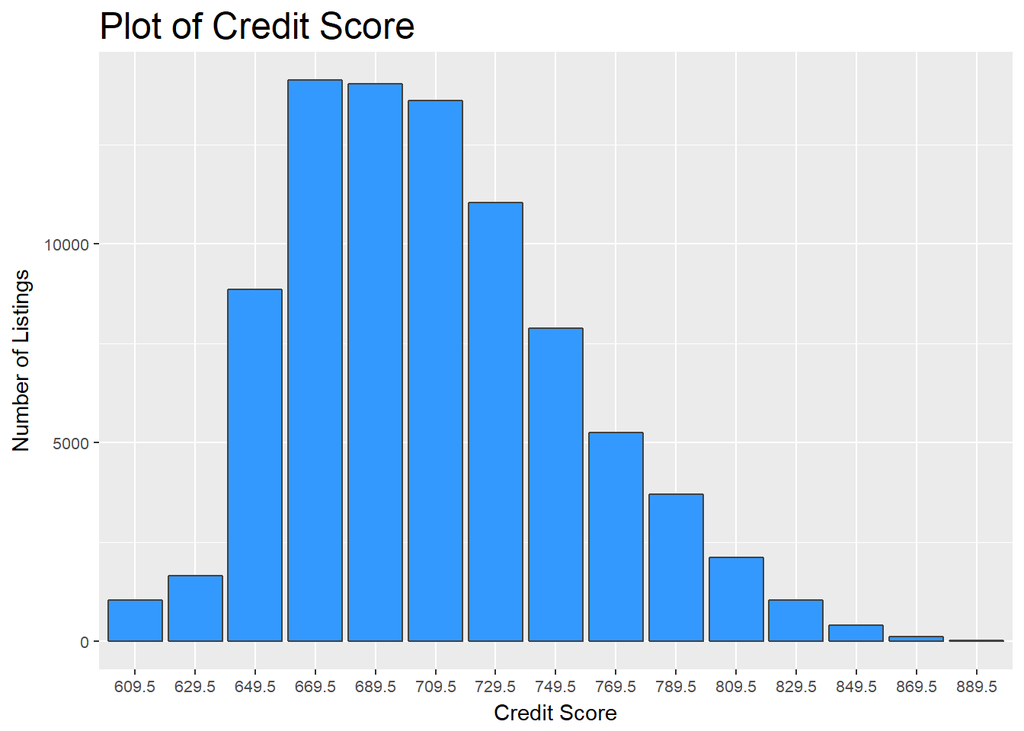

Using a barplot of factored credit score, we can clearly see that the majority of the users lie between the 650 and 750 mark, which are decent credit scores, highest beimg 669.5.

Plot of BorrowerRate :

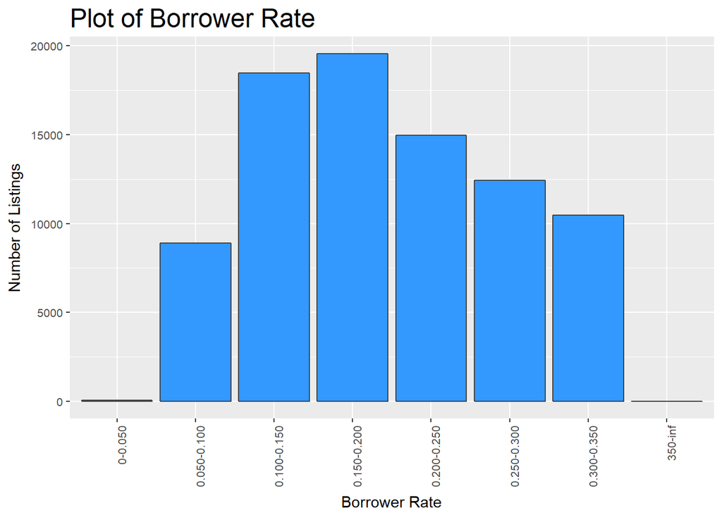

Borrower Rate or The Borrower’s interest rate for loan peaks between 0.150 and 0.200.

```
##     0-0.050 0.050-0.100 0.100-0.150 0.150-0.200 0.200-0.250 0.250-0.300
##          55        8903       18479       19556       14966       12417
## 0.300-0.350     350-inf
##       10472           5
```

Plot of Borrower State:

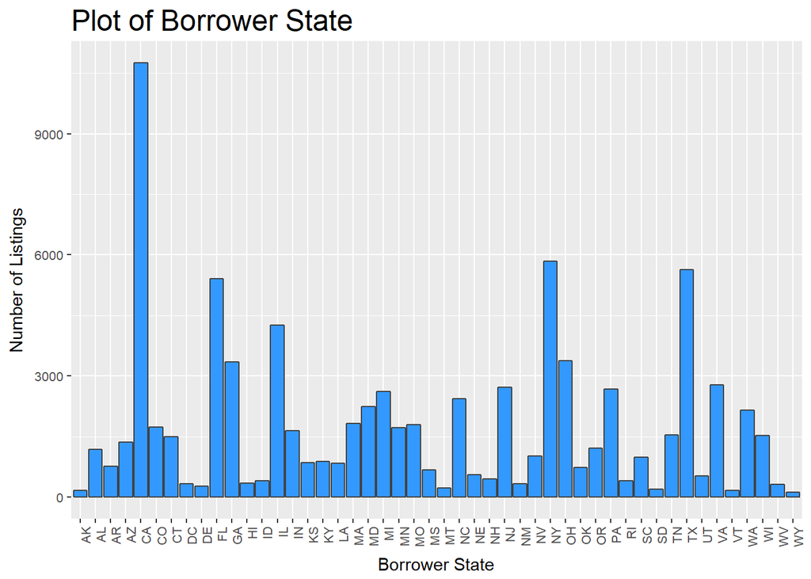

This histogram shows the highest listing counts in CA, FL,IL,NY,TX. which tracks with the rankings of top US states by population. In other words, geographically, the Prosper listings are distributed similarly to the population of the US.

Plot of Income Range :

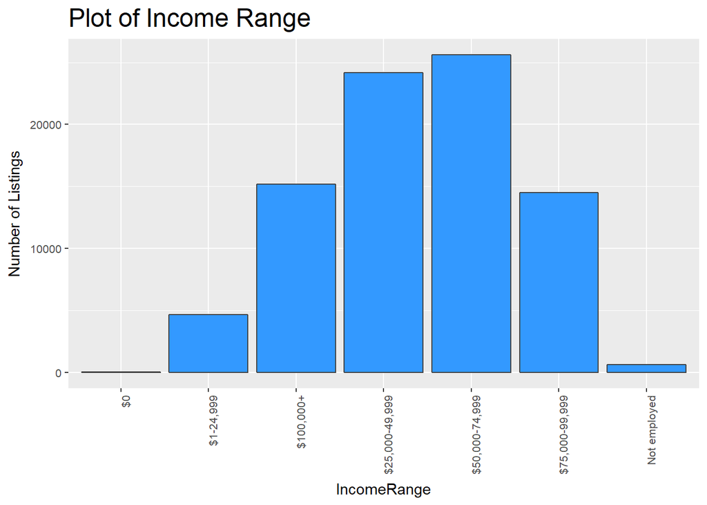

Income range of the majority of the borrowers ar below $75000 per annuam. This clearly explains their need of loans, especially for reasons like consolidaitng the credit card debts.

Plot of DebtToIncomeRatio:

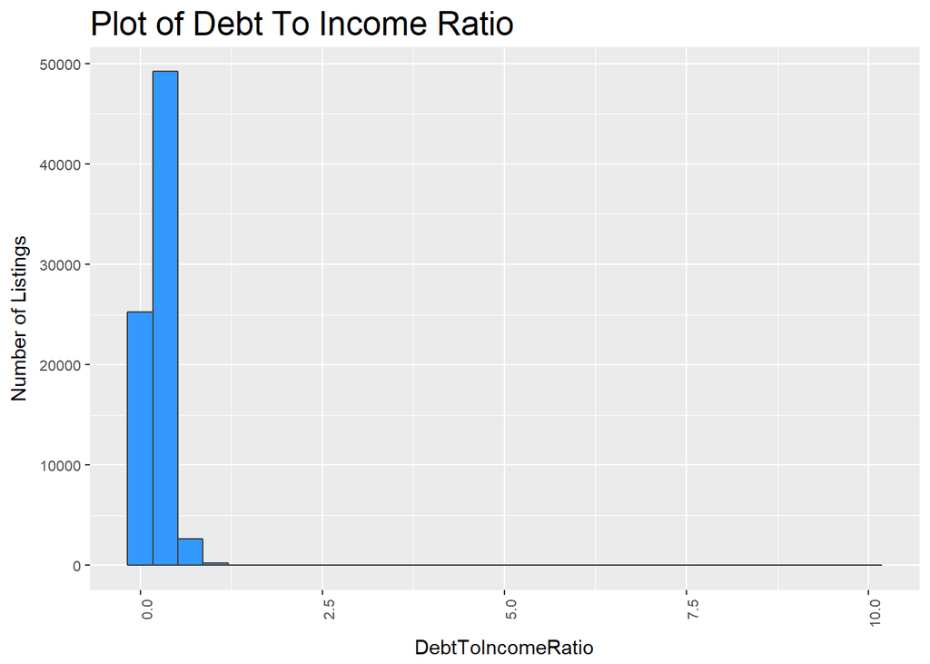

```
##    Min. 1st Qu.  Median    Mean 3rd Qu.    Max.
##  0.0000  0.1500  0.2200  0.2588  0.3200 10.0100
```

It looks like there is some outliers in data.It is very evident looking at the summary of Debt to Income Ratio.Now Let’s try to plot the variable again eliminating the ouliers.

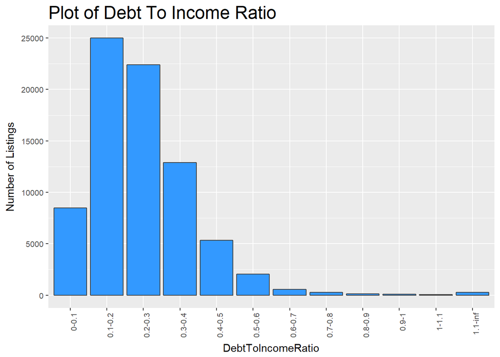

Plot of Term:

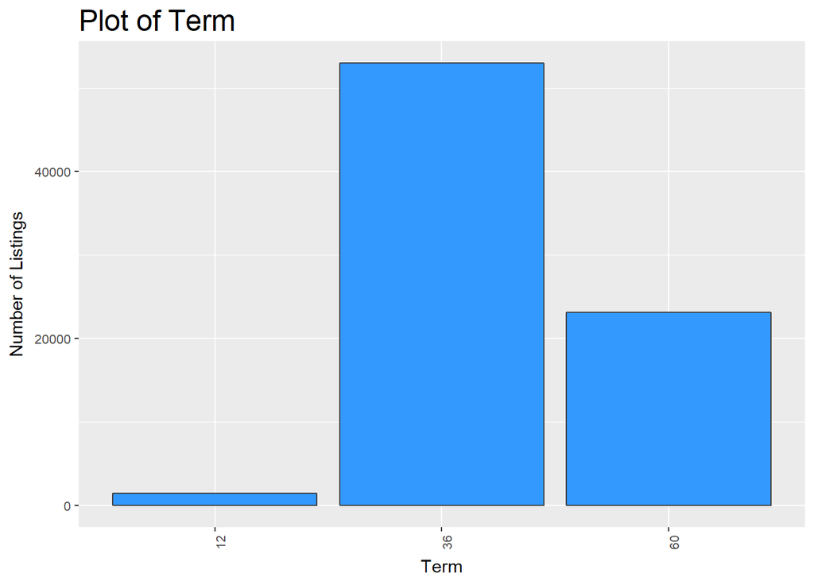

Just like in every other loans,Loan terms here are either 12, 36, or 60 months, with the vast majority being 36-months.Since majority of Loan Amount lies below 35000, and borrowers anuual income less than 75000 per annuam, a spike in the loan term of 36 months is reasonable.

Plot of Lender Yield:

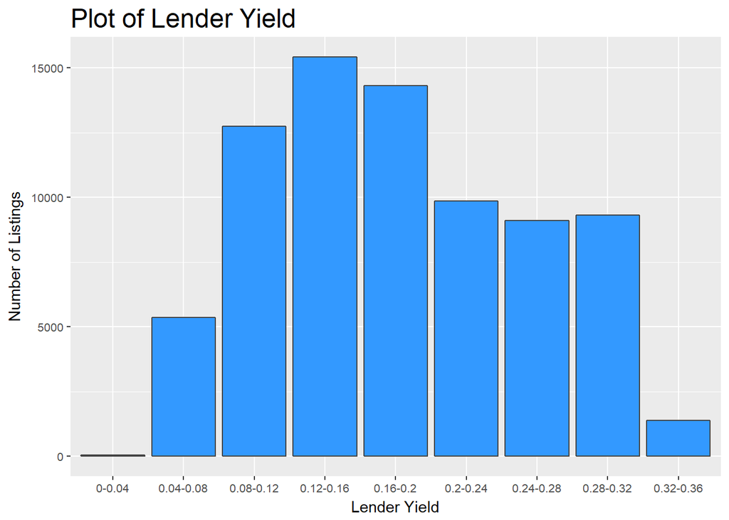

```
##    0-0.04 0.04-0.08 0.08-0.12 0.12-0.16  0.16-0.2  0.2-0.24 0.24-0.28
##        54      5369     12741     15428     14305      9859      9110
## 0.28-0.32 0.32-0.36  0.36-0.4   0.4-inf
##      9303      1388         0         0
```

Most yields range from 0.12-0.32. The highest peak in the graphic is between 0.12-0.16,This observation might prompt the lenders to rethink about these kind of investments,whether they should be doing it again or not.

Plot of EmploymentStatusDuration

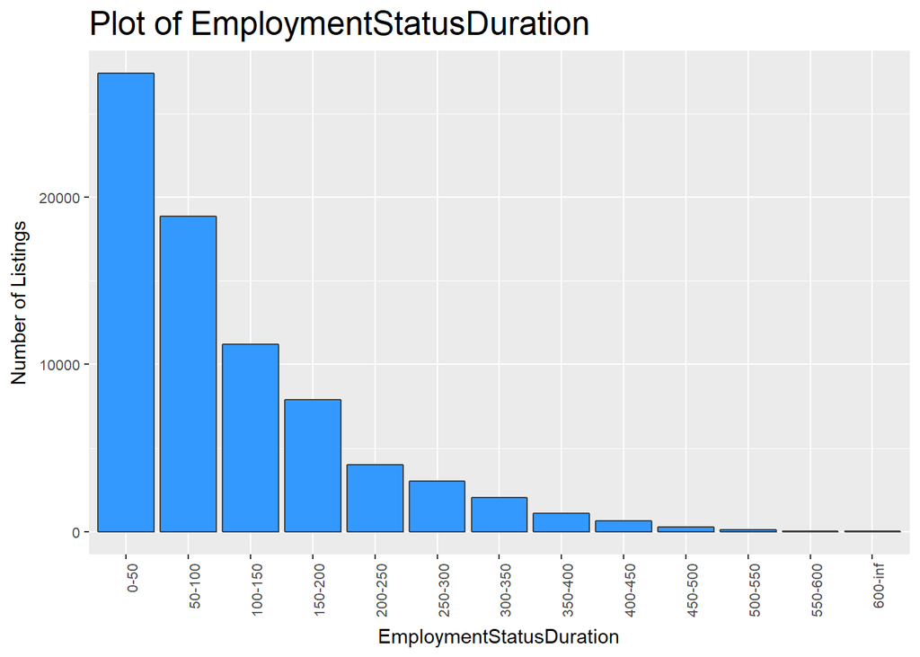

Plot of AmountDelinquent:

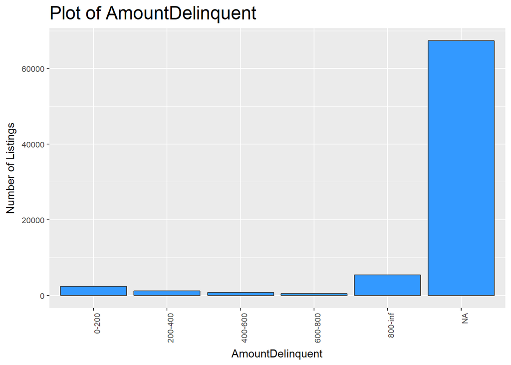

Plot of EstimatedEffectiveYield

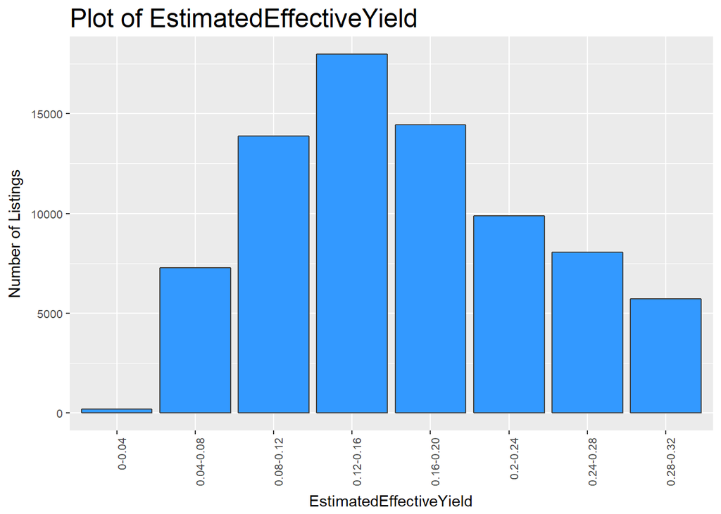

Univariate Analysis

What is the structure of your dataset?

The data set contains 113,937 loans with 81 variables on each loan. The dataset contains loans created between 2005-Q4 and 2014-Q1. The data seems “tidy,” according to Hadley Wickham’s definition: the variable names are not variables themselves, so there is not much work required in the way of “tidying” the data.

What other features in the dataset do you think will help support your  
investigation into your feature(s) of interest?

From 2006 to 2009 Prosper operated a variable rate model. In 2010, Prosper changedits business model to use pre-set rates determined solely by Prosper based on a formula evaluating each prospective borrower’s credit risk. Under this new a pproach, lenders no longer determine the loan rate via price discovery in an auction. Instead, they simply choose whether or not to invest at the rate which Prosper’s loan pricing algorithm assigns to the loan after it analyzes the borrower’s credit report and financial information.Also following the SEC registration, the company created a new model that determined “Prosper Ratings” instead of credit grade.Iam really interested to see how these cheanges affected Prosper’s business over the years.My main investigation will be into how Prosper’s credit policies and borrower characteristics changed over time as its business model and the larger lending environment evolved. So having the Loan Origination Quarter is critical. And being able to see how much Prosper’s lenders earned or lost on each loan with the Payments, Fees, and Loss fields could prove helpful in illuminating what is going on with these loans.

Did you create any new variables from existing variables in the dataset? yes.I created 7 new variables: Listing Category,LoanOriginationQuarter_factor,LoanStatusRecoded, CreditScore, CreditRating,LoanPaymentPercentage,CurrentDelinquencies_factored.In addition 11 new variables were created for the purpose of converting ordinal categorical variable into numeric while plotting the graphs.

Of the features you investigated, were there any unusual distributions?  
Did you perform any operations on the data to tidy, adjust, or change the form  
of the data? If so, why did you do this?

The main “unusual” distribution that stood out was the number of loans originated in each quarter, and how that number dipped to zero in early 2009.

# 2. Bivariate Plots Section

Plot of Loan Status vs Credit Score

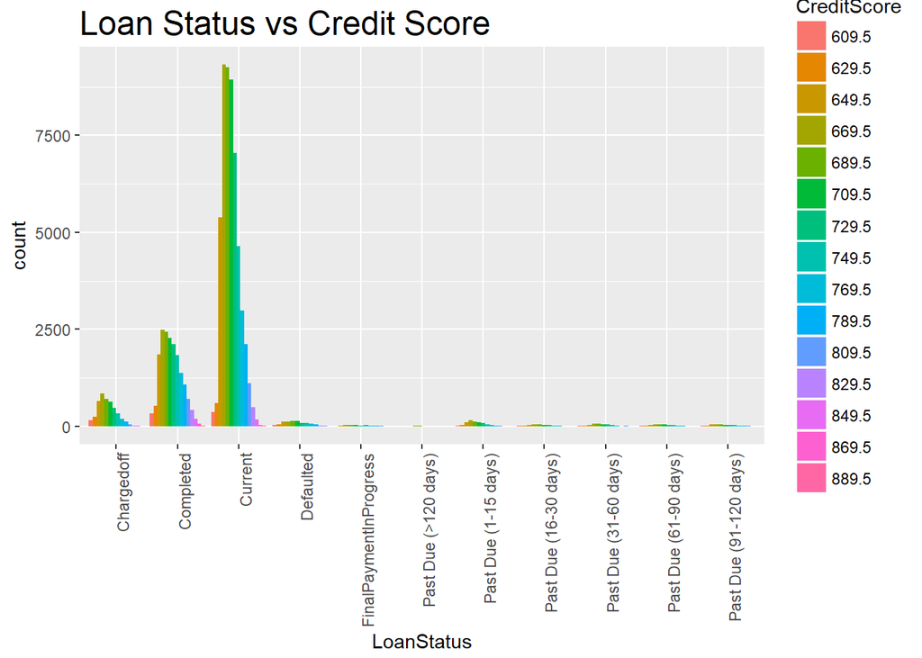

[output not shown]

[output cut: 79 more lines]

```
##     0     0    15     7     2     3     0     0     0     0     0     0
##  1409   567   212    27
##     0     0     0     0
## --------------------------------------------------------
## Prosper_Loans$LoanStatus: Past Due (91-120 days)
##   9.5 369.5 429.5 449.5 469.5 489.5 509.5 529.5 549.5 569.5 589.5 609.5
##     0     0     0     0     0     0     0     0     0     0     0     6
## 629.5 649.5 669.5 689.5 709.5 729.5 749.5   133     1     5    36   141
##    13    45    45    49    33    30    22     0     0     0     0     0
##   346   554  1593  1474  1357  1125  3602  4172 12199 16366 16492  5471
##     0     0     0     0     0     0     0     0     0     0     0     0
## 12923  9267 769.5 789.5 809.5 829.5 849.5 869.5 889.5  6606  4624  2644
##     0     0    18     7     5     4     0     0     0     0     0     0
##  1409   567   212    27
##     0     0     0     0
```

From looking at the plot and by() function, we see that median credit score is high for categories Completed and FinalPaymentInProgress.Higher financial stability,bettercredit score,sooner the loan will be closed.

Plot of LoanStatus Vs ProsperScore :

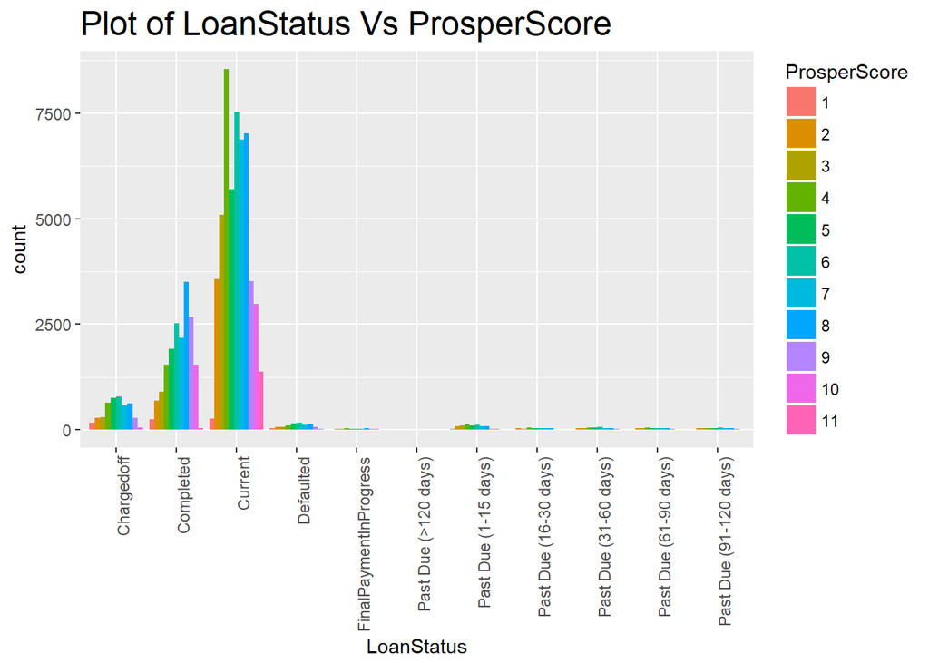

```
## Prosper_Loans$LoanStatus: Cancelled
## NULL
## --------------------------------------------------------
## Prosper_Loans$LoanStatus: Chargedoff
##     1     2     3     4     5     6     7     8     9    10    11   721
##   160   277   303   639   752   780   570   623   286    55     0     0
##  4822  6580 11164  8776 11309  9966 11543  6625  4639  1412
##     0     0     0     0     0     0     0     0     0     0
## --------------------------------------------------------
## Prosper_Loans$LoanStatus: Completed
##     1     2     3     4     5     6     7     8     9    10    11   721
##   238   682   896  1538  1913  2521  2176  3501  2672  1536    30     0
##  4822  6580 11164  8776 11309  9966 11543  6625  4639  1412
##     0     0     0     0     0     0     0     0     0     0
## --------------------------------------------------------
## Prosper_Loans$LoanStatus: Current
##     1     2     3     4     5     6     7     8     9    10    11   721
##   257  3563  5093  8548  5691  7534  6878  7030  3520  2987  1377     0
##  4822  6580 11164  8776 11309  9966 11543  6625  4639  1412
##     0     0     0     0     0     0     0     0     0     0
## --------------------------------------------------------
## Prosper_Loans$LoanStatus: Defaulted
##     1     2     3     4     5     6     7     8     9    10    11   721
##    31    61    60    93   144   159   122   127    68    20     0     0
##  4822  6580 11164  8776 11309  9966 11543  6625  4639  1412
##     0     0     0     0     0     0     0     0     0     0
## --------------------------------------------------------
## Prosper_Loans$LoanStatus: FinalPaymentInProgress
##     1     2     3     4     5     6     7     8     9    10    11   721
##     2    23    15    25    22    22    15    38    13    11     3     0
##  4822  6580 11164  8776 11309  9966 11543  6625  4639  1412
##     0     0     0     0     0     0     0     0     0     0
## --------------------------------------------------------
## Prosper_Loans$LoanStatus: Past Due (>120 days)
##     1     2     3     4     5     6     7     8     9    10    11   721
##     0     2     3     1     3     1     1     3     0     0     0     0
##  4822  6580 11164  8776 11309  9966 11543  6625  4639  1412
##     0     0     0     0     0     0     0     0     0     0
## --------------------------------------------------------
## Prosper_Loans$LoanStatus: Past Due (1-15 days)
```

[output cut: 13 more lines]

```
##     3    38    38    49    45    60    39    38     9     8     0     0
##  4822  6580 11164  8776 11309  9966 11543  6625  4639  1412
##     0     0     0     0     0     0     0     0     0     0
## --------------------------------------------------------
## Prosper_Loans$LoanStatus: Past Due (61-90 days)
##     1     2     3     4     5     6     7     8     9    10    11   721
##     3    39    35    44    35    37    35    35     9     2     1     0
##  4822  6580 11164  8776 11309  9966 11543  6625  4639  1412
##     0     0     0     0     0     0     0     0     0     0
## --------------------------------------------------------
## Prosper_Loans$LoanStatus: Past Due (91-120 days)
##     1     2     3     4     5     6     7     8     9    10    11   721
##     8    31    26    40    36    52    26    37    16     5     0     0
##  4822  6580 11164  8776 11309  9966 11543  6625  4639  1412
##     0     0     0     0     0     0     0     0     0     0
```

From looking at the plot and by() function, we see that median credit score is high for category Completed.Higher financial stability,bettercredit score,sooner the loan will be closed.

Plot of Loan Original Amount Vs Loan origination Quarter.

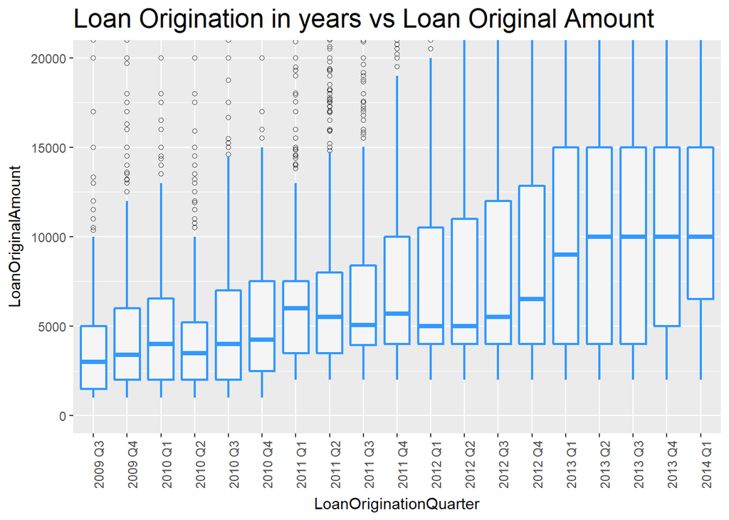

Plot of Prosper Rating(Alpha) Vs Borrower APR

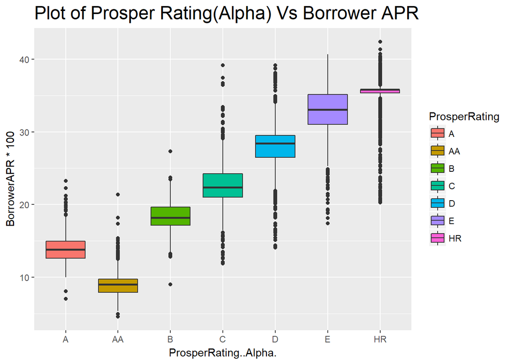

```
## Prosper_Loans$ProsperRating..Alpha.:
## NULL
## --------------------------------------------------------
## Prosper_Loans$ProsperRating..Alpha.: A
##    Min. 1st Qu.  Median    Mean 3rd Qu.    Max.
##    5.00    9.99   11.19   11.30   12.39   20.98
## --------------------------------------------------------
## Prosper_Loans$ProsperRating..Alpha.: AA
##    Min. 1st Qu.  Median    Mean 3rd Qu.    Max.
##   4.000   6.990   7.790   7.906   8.490  21.000
## --------------------------------------------------------
## Prosper_Loans$ProsperRating..Alpha.: B
##    Min. 1st Qu.  Median    Mean 3rd Qu.    Max.
##    6.93   14.14   15.09   15.46   16.49   25.00
## --------------------------------------------------------
## Prosper_Loans$ProsperRating..Alpha.: C
##    Min. 1st Qu.  Median    Mean 3rd Qu.    Max.
##    8.95   17.65   19.14   19.43   20.99   35.00
## --------------------------------------------------------
## Prosper_Loans$ProsperRating..Alpha.: D
##    Min. 1st Qu.  Median    Mean 3rd Qu.    Max.
##   11.58   22.87   24.89   24.60   26.24   35.00
## --------------------------------------------------------
## Prosper_Loans$ProsperRating..Alpha.: E
##    Min. 1st Qu.  Median    Mean 3rd Qu.    Max.
##   15.18   27.12   29.25   29.29   31.49   36.00
## --------------------------------------------------------
## Prosper_Loans$ProsperRating..Alpha.: HR
##    Min. 1st Qu.  Median    Mean 3rd Qu.    Max.
##   17.79   31.34   31.77   31.76   31.77   36.00
```

Plot of ProsperRating(Alpha) vs DebtToIncomeRatio :

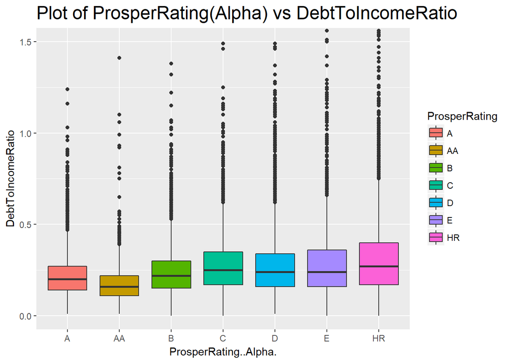

Plot of Prosper Score vs Borrower rate :

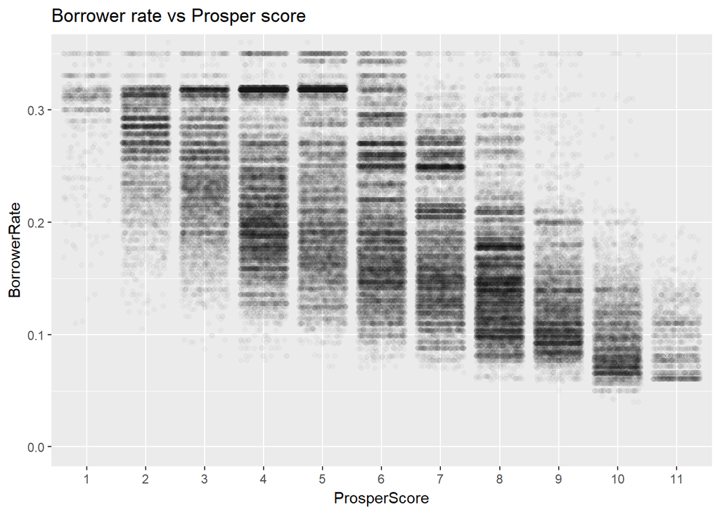

This scatterplot shows a negative correlation between Prosper Score and Borrower rate.As the Prosperscore increases,the borrower rate decreases.

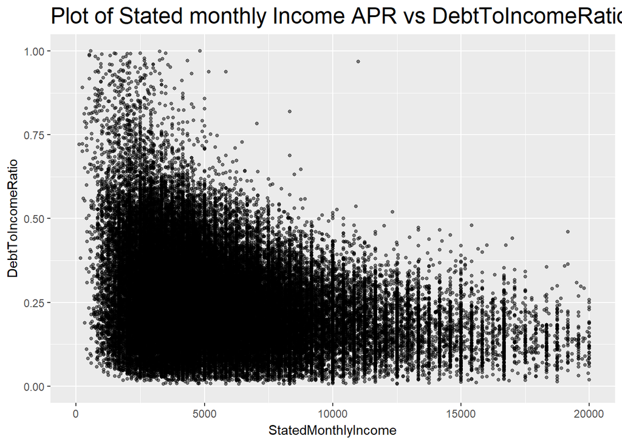

In comparing debt-to-income ratio with a borrower’s stated monthly income I was expecting to see a somewhat obvious, trend that delinquent borrowers would have a lower monthly income and a higher debt-to-income ratio. With overplotting in the scatterplot we couldn’t clearly reveal any trends or unexpected results.

Borrwers with stated incomes over $20k and debt-to-income ratios over 1 were considered as outliers and removed from the plot.The plot also suggests a negative correlation between monthly income and debt-to-income ratio, i.e the more a borrower makes in monthly income the lower their debt-to-income ratio; However, this does not guarantee the loan will not go into delinquency.

After further review from multiple online resources, it seems that a typical “good” debt-to-income ratio is under approx. 36%.

Plot of DelinquenciesLast7Years Vs AmountDelinquent

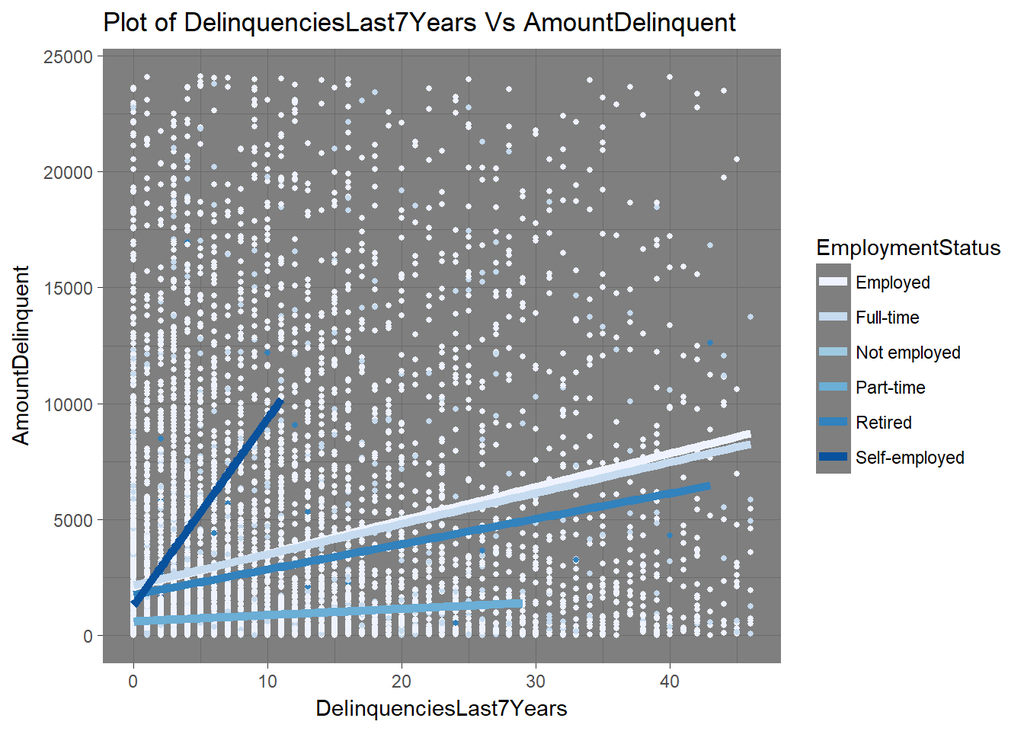

This plot doesn’t reveal much. I wanted to see the relationship between the amount borrowers were delinquent and the number of delinquencies they’ve had over the last 7 years. I then separated that by employment status to see if people that weren’t full employed had higher delinquencies or owed more money. The overplotting and general dispersion of data doesn’t really reveal the trend I hypothesized.

Bivariate Analysis

Talk about some of the relationships you observed in this part of the  
investigation. How did the feature(s) of interest vary with other features in  
the dataset? Borrowers who completed the loans have a higher credit score,This is a trend which we observe in our common day to day life.Better the financial stability, lesser the debt.

As we go down the Prosper Rating categories of level of risk - from a ‘High Risk’ to an ‘AA’ rating - the APR forthe borrower reduces drastically.

There is a negative correlation between monthly income and debt-to-income ratio.

Did you observe any interesting relationships between the other features  
(not the main feature(s) of interest)?

What was the strongest relationship you found? There is a negative correlation between monthly income and debt-to-income ratio. As we go down the Prosper Rating categories of level of risk - from a ‘High Risk’ to an ‘AA’ rating - the APR for the borrower reduces drastically.As we go down the Prosper Rating categories of level of risk - from a ‘High Risk’ to an ‘AA’ rating - the debt to income ratio of the borrower reduces slightly.

Multivariate Plots Section:

Plot of Loan Amount vs Lender Yield :

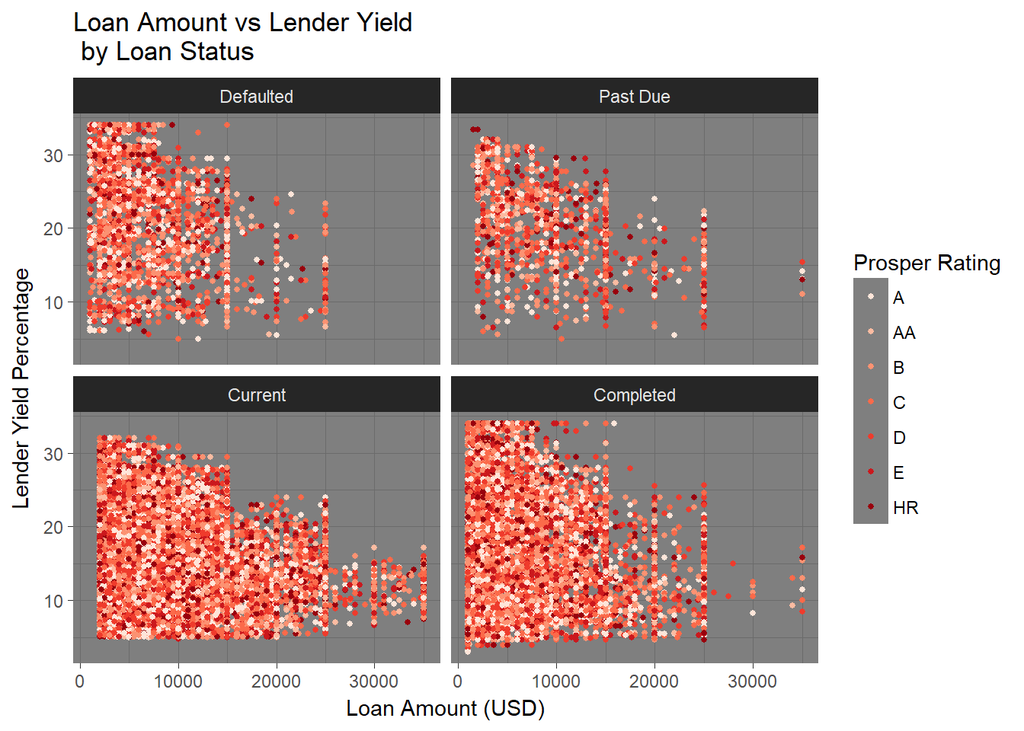

Here I created a plot between Loan amount and percentage of lender yeild,based on then category of Loan status.

Plot of DebtToIncomeRatio and BorrowerAPR:

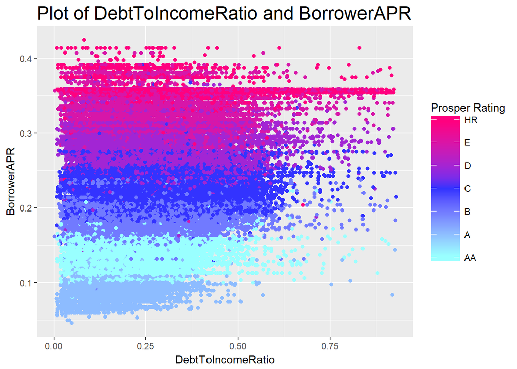

This is a scatterplot of Debt to income ratio of the borrower and Borrower APR, with the colors describing the Prosper ratings given to the particular loan. I decided to include all points in the y-axis (including outliers) to show the range of rates, and I’ve limited the x-axis by removing 0.05% of the points furthest away from the median (i.e. removing outliers that spread the graph).

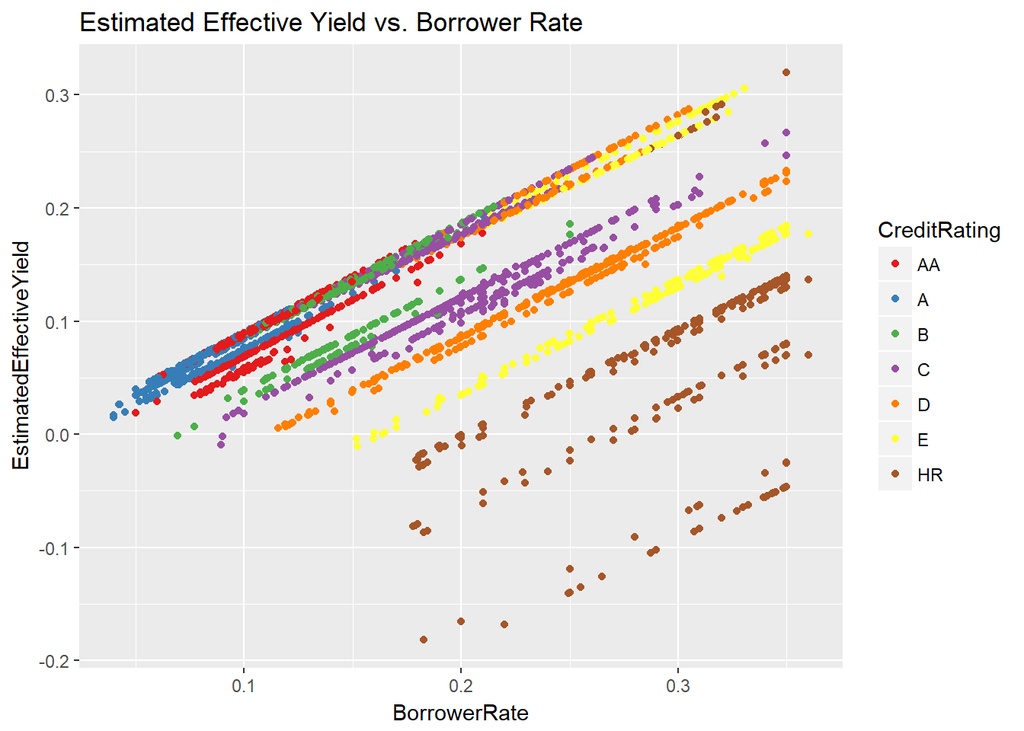

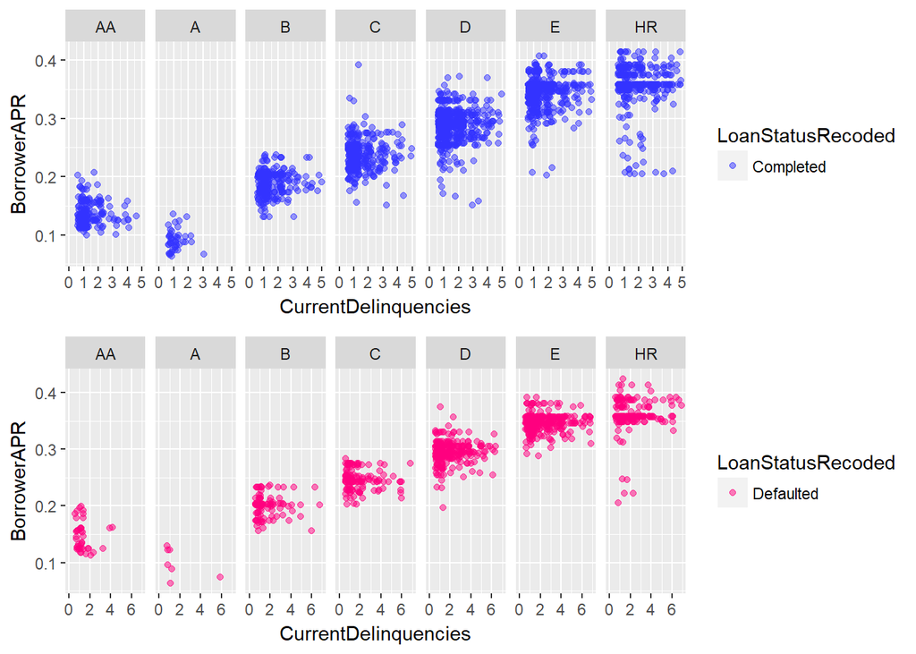

Multivariate Analysis

Were there any interesting or surprising interactions between features?